# Climate change netcdf data exploration for Maryland

# Lesson Goals

in this lesson, you will learn how to calculate seasonal averages over several years using MACA v 2 Climate Data downloaded in netcdf4 format using xarray. In this example you will use the forecast temperature data downloaded from the northwestknowledge.net website.

# Prerequests

1. Install the below mentioned libraries

NB:make sure for possible update of software modules, libraries. this lesson prepare by using anaconda 3.7.1

```python
import os

import numpy as np
import pandas as pd
import matplotlib.pyplot as plt
import cartopy.crs as ccrs
import cartopy.feature as cfeature
import seaborn as sns
import geopandas as gpd
import earthpy as et
import xarray as xr
import regionmask

# Plotting options
sns.set(font_scale=1.3)
sns.set_style("white")
```

```python
# Get netcdf file
data_path_monthly = 'http://thredds.northwestknowledge.net:8080/thredds/dodsC/agg_macav2metdata_tasmax_BNU-ESM_r1i1p1_rcp45_2006_2099_CONUS_monthly.nc'

# Open up the data
with xr.open_dataset(data_path_monthly) as file_nc:
    monthly_forecast_temp_xr = file_nc

# xarray object
monthly_forecast_temp_xr
```

```
<xarray.Dataset>
Dimensions:          (crs: 1, lat: 585, lon: 1386, time: 1128)
Coordinates:
  * lat              (lat) float64 25.06 25.1 25.15 25.19 ... 49.31 49.35 49.4
  * crs              (crs) int32 1
  * lon              (lon) float64 235.2 235.3 235.3 235.4 ... 292.9 292.9 292.9
  * time             (time) object 2006-01-15 00:00:00 ... 2099-12-15 00:00:00
Data variables:
    air_temperature  (time, lat, lon) float32 ...
Attributes:
    description:                     Multivariate Adaptive Constructed Analog...
    id:                              MACAv2-METDATA
    naming_authority:                edu.uidaho.reacch
    Metadata_Conventions:            Unidata Dataset Discovery v1.0
    Metadata_Link:
    cdm_data_type:                   FLOAT
    title:                           Monthly aggregation of downscaled daily ...
    summary:                         This archive contains monthly downscaled...
    keywords:                        monthly, precipitation, maximum temperat...
    keywords_vocabulary:
    standard_name_vocabulary:        CF-1.0
    history:                         No revisions.
    comment:
    geospatial_bounds:               POLYGON((-124.7722 25.0631,-124.7722 49....
    geospatial_lat_min:              25.0631
    geospatial_lat_max:              49.3960
    geospatial_lon_min:              -124.7722
    geospatial_lon_max:              -67.0648
    geospatial_lat_units:            decimal degrees north
    geospatial_lon_units:            decimal degrees east
    geospatial_lat_resolution:       0.0417
    geospatial_lon_resolution:       0.0417
    geospatial_vertical_min:         0.0
    geospatial_vertical_max:         0.0
    geospatial_vertical_resolution:  0.0
    geospatial_vertical_positive:    up
    time_coverage_start:             2091-01-01T00:0
    time_coverage_end:               2095-12-31T00:00
    time_coverage_duration:          P5Y
    time_coverage_resolution:        P1M
    date_created:                    2014-05-15
    date_modified:                   2014-05-15
    date_issued:                     2014-05-15
    creator_name:                    John Abatzoglou
    creator_url:                     http://maca.northwestknowledge.net
    creator_email:                   jabatzoglou@uidaho.edu
    institution:                     University of Idaho
    processing_level:                GRID
    project:
    contributor_name:                Katherine C. Hegewisch
    contributor_role:                Postdoctoral Fellow
    publisher_name:                  REACCH
    publisher_email:                 reacch@uidaho.edu
    publisher_url:                   http://www.reacchpna.org/
    license:                         Creative Commons CC0 1.0 Universal Dedic...
    coordinate_system:               WGS84,EPSG:4326
```

```python
# Download natural earth data to generate AOI
et.data.get_data(
    url="https://www.naturalearthdata.com/http//www.naturalearthdata.com/download/50m/cultural/ne_50m_admin_1_states_provinces_lakes.zip")

states_path = "C:/Users/agurm/earth-analytics/data/earthpy-downloads/ne_50m_admin_1_states_provinces_lakes/ne_50m_admin_1_states_provinces_lakes.shp"

states_gdf = gpd.read_file(states_path)
mary_aoi = states_gdf[states_gdf.name == "Maryland"]
```

```python
# Would this be better if it only returned 4 values?? probably so
# Helper Function to extract AOI
def get_aoi(shp, world=True):
    """Takes a geopandas object and converts it to a lat/ lon
    extent """

    lon_lat = {}
    # Get lat min, max
    aoi_lat = [float(shp.total_bounds[1]), float(shp.total_bounds[3])]
    aoi_lon = [float(shp.total_bounds[0]), float(shp.total_bounds[2])]

    # Handle the 0-360 lon values
    if world:
        aoi_lon[0] = aoi_lon[0] + 360
        aoi_lon[1] = aoi_lon[1] + 360
    lon_lat["lon"] = aoi_lon
    lon_lat["lat"] = aoi_lat
    return lon_lat
```

```python
# Get lat min, max from mary aoi extent
mary_bounds = get_aoi(mary_aoi)

# Slice by time & aoi location
start_date = "2018-12-15"
end_date = "2050-12-15"

mary_temp = monthly_forecast_temp_xr["air_temperature"].sel(
    time=slice(start_date, end_date),
    lon=slice(mary_bounds["lon"][0], mary_bounds["lon"][1]),
    lat=slice(mary_bounds["lat"][0], mary_bounds["lat"][1]))
mary_temp
```

```
<xarray.DataArray 'air_temperature' (time: 385, lat: 42, lon: 107)>
[1730190 values with dtype=float32]
Coordinates:
  * lat      (lat) float64 37.98 38.02 38.06 38.1 ... 39.56 39.6 39.65 39.69
  * lon      (lon) float64 280.5 280.6 280.6 280.6 ... 284.8 284.9 284.9 284.9
  * time     (time) object 2018-12-15 00:00:00 ... 2050-12-15 00:00:00
Attributes:
    long_name:      Monthly Average of Daily Maximum Near-Surface Air Tempera...
    units:          K
    grid_mapping:   crs
    standard_name:  air_temperature
    height:         2 m
    cell_methods:   time: maximum(interval: 24 hours);mean over days
    _ChunkSizes:    [ 10  44 107]
```

```python
print("Time Period start: ", mary_temp.time.min().values)
print("Time Period end: ", mary_temp.time.max().values)
```

```
Time Period start:  2018-12-15 00:00:00
Time Period end:  2050-12-15 00:00:00
```

```python
# Create the region mask object - this is used to identify each region
mary_region = regionmask.from_geopandas(mary_aoi,
                                        names="name",
                                       name="name",
                                       abbrevs="iso_3166_2")
mary_mask = regionmask.mask_3D_geopandas(mary_aoi,
                                         monthly_forecast_temp_xr.lon,
                                         monthly_forecast_temp_xr.lat)
# Mask the netcdf data
mary_temp_masked = mary_temp.where(mary_mask)
mary_temp_masked.dims
```

```
('time', 'lat', 'lon', 'region')
```

```python
mary_temp.values.shape
```

```
(385, 42, 107)
```

```python
mary_season_summary = mary_temp_masked.groupby(
    'time.season').mean('time', skipna=True)

# This will create 4 arrays - one for each season showing mean temperature values
mary_season_summary.shape
```

```
(4, 42, 107, 1)
```

# Plot the seasonal data.

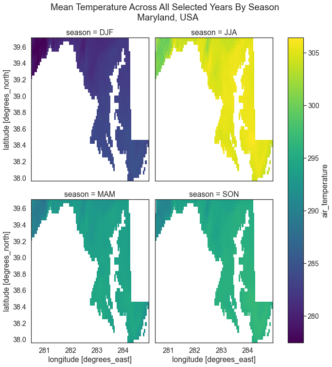

```python
# Create a plot showing mean temperature aross seasons
mary_season_summary.plot(col='season', col_wrap=2, figsize=(10, 10))
plt.suptitle("Mean Temperature Across All Selected Years By Season \n Maryland, USA",
             y=1.05)

plt.show()
```

## Calculate UnWeighted Seasonal Averages For By Season Across Each Year

```python
# Resample the data by season across all years
mary_season_mean_all_years = mary_temp_masked.resample(
    time='QS-DEC', skipna=False, keep_attrs=True).mean()
mary_season_mean_all_years.shape
```

```
(129, 42, 107, 1)
```

```python
# Summarize each array into one single (mean) value
mary_seasonal_mean = mary_season_mean_all_years.groupby('time').mean([
    "lat", "lon"])
mary_seasonal_mean.shape
```

```
(129, 1)
```

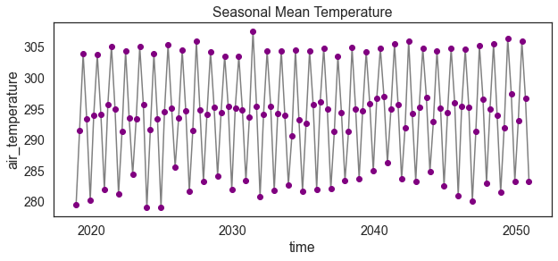

```python
# Plot the data
f, ax = plt.subplots(figsize=(10, 4))
mary_seasonal_mean.plot(marker="o",
                        color="grey",
                        markerfacecolor="purple",
                        markeredgecolor="purple")
ax.set(title="Seasonal Mean Temperature")
plt.show()
```

```python
# Convert to a dataframe
mary_seasonal_mean_df = mary_seasonal_mean.to_dataframe()
mary_seasonal_mean_df
```

| time | region | air_temperature |
| --- | --- | --- |
| 2018-12-01 00:00:00 | 69 | 279.427368 |
| 2019-03-01 00:00:00 | 69 | 291.451172 |
| 2019-06-01 00:00:00 | 69 | 303.863251 |
| 2019-09-01 00:00:00 | 69 | 293.349152 |
| 2019-12-01 00:00:00 | 69 | 280.192749 |
| ... | ... | ... |
| 2049-12-01 00:00:00 | 69 | 283.282684 |
| 2050-03-01 00:00:00 | 69 | 293.103882 |
| 2050-06-01 00:00:00 | 69 | 305.870575 |
| 2050-09-01 00:00:00 | 69 | 296.726105 |
| 2050-12-01 00:00:00 | 69 | 283.319733 |

129 rows × 1 columns

## Export Seasonal Climate Project Data To .csv File

```python
# Export a csv file
mary_seasonal_mean_df.to_csv("mary-seasonal-temp.csv")
```

## Plot Seasonal Data By Season

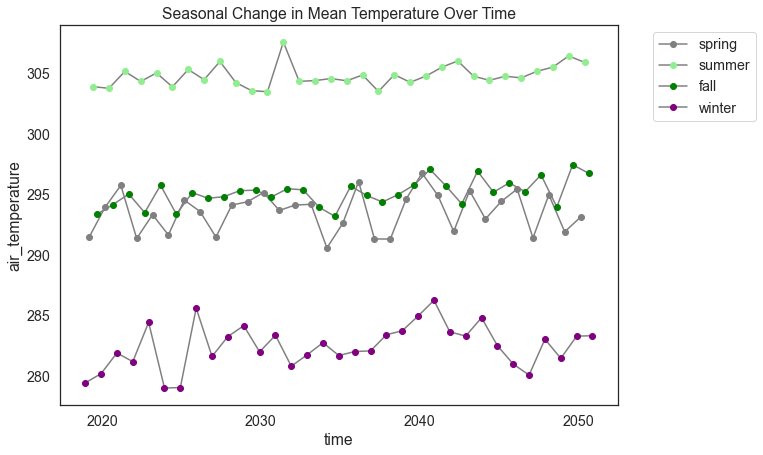

```python
colors = {3: "grey", 6: "lightgreen", 9: "green", 12: "purple"}
seasons = {3: "spring", 6: "summer", 9: "fall", 12: "winter"}

f, ax = plt.subplots(figsize=(10, 7))
for month, arr in mary_seasonal_mean.groupby('time.month'):
    arr.plot(ax=ax,
             color="grey",
             marker="o",
             markerfacecolor=colors[month],
             markeredgecolor=colors[month],
             label=seasons[month])

ax.legend(bbox_to_anchor=(1.05, 1), loc='upper left')
ax.set(title="Seasonal Change in Mean Temperature Over Time")
plt.show()
```

[figure not shown]

```python
colors = {3: "grey", 6: "lightgreen", 9: "green", 12: "purple"}
seasons = {3: "spring", 6: "summer", 9: "fall", 12: "winter"}

f, ax = plt.subplots(figsize=(10, 7))
for month, arr in mary_seasonal_mean.groupby('time.month'):
    arr.plot(ax=ax,
             color="grey",
             marker="o",
             markerfacecolor=colors[month],
             markeredgecolor=colors[month],
             label=seasons[month])

ax.legend(bbox_to_anchor=(1.05, 1), loc='upper left')
ax.set(title="Seasonal Change in Mean Temperature Over Time")
plt.show()
```

## Weighted Summary by Season

```python
# Calculate seasonal averages
# http://xarray.pydata.org/en/stable/examples/monthly-means.html

month_length = mary_temp_masked.time.dt.days_in_month
month_length
```

```
<xarray.DataArray 'days_in_month' (time: 385)>
array([31, 31, 28, 31, 30, 31, 30, 31, 31, 30, 31, 30, 31, 31, 28, 31, 30,
       31, 30, 31, 31, 30, 31, 30, 31, 31, 28, 31, 30, 31, 30, 31, 31, 30,
       31, 30, 31, 31, 28, 31, 30, 31, 30, 31, 31, 30, 31, 30, 31, 31, 28,
       31, 30, 31, 30, 31, 31, 30, 31, 30, 31, 31, 28, 31, 30, 31, 30, 31,
       31, 30, 31, 30, 31, 31, 28, 31, 30, 31, 30, 31, 31, 30, 31, 30, 31,
       31, 28, 31, 30, 31, 30, 31, 31, 30, 31, 30, 31, 31, 28, 31, 30, 31,
       30, 31, 31, 30, 31, 30, 31, 31, 28, 31, 30, 31, 30, 31, 31, 30, 31,
       30, 31, 31, 28, 31, 30, 31, 30, 31, 31, 30, 31, 30, 31, 31, 28, 31,
       30, 31, 30, 31, 31, 30, 31, 30, 31, 31, 28, 31, 30, 31, 30, 31, 31,
       30, 31, 30, 31, 31, 28, 31, 30, 31, 30, 31, 31, 30, 31, 30, 31, 31,
       28, 31, 30, 31, 30, 31, 31, 30, 31, 30, 31, 31, 28, 31, 30, 31, 30,
       31, 31, 30, 31, 30, 31, 31, 28, 31, 30, 31, 30, 31, 31, 30, 31, 30,
       31, 31, 28, 31, 30, 31, 30, 31, 31, 30, 31, 30, 31, 31, 28, 31, 30,
       31, 30, 31, 31, 30, 31, 30, 31, 31, 28, 31, 30, 31, 30, 31, 31, 30,
       31, 30, 31, 31, 28, 31, 30, 31, 30, 31, 31, 30, 31, 30, 31, 31, 28,
       31, 30, 31, 30, 31, 31, 30, 31, 30, 31, 31, 28, 31, 30, 31, 30, 31,
       31, 30, 31, 30, 31, 31, 28, 31, 30, 31, 30, 31, 31, 30, 31, 30, 31,
       31, 28, 31, 30, 31, 30, 31, 31, 30, 31, 30, 31, 31, 28, 31, 30, 31,
       30, 31, 31, 30, 31, 30, 31, 31, 28, 31, 30, 31, 30, 31, 31, 30, 31,
       30, 31, 31, 28, 31, 30, 31, 30, 31, 31, 30, 31, 30, 31, 31, 28, 31,
       30, 31, 30, 31, 31, 30, 31, 30, 31, 31, 28, 31, 30, 31, 30, 31, 31,
       30, 31, 30, 31, 31, 28, 31, 30, 31, 30, 31, 31, 30, 31, 30, 31, 31,
       28, 31, 30, 31, 30, 31, 31, 30, 31, 30, 31])
Coordinates:
  * time     (time) object 2018-12-15 00:00:00 ... 2050-12-15 00:00:00
```

```python
# This is returning values of 0 rather than na
# Calculate a weighted mean by season
mary_weighted_mean = ((mary_temp * month_length).resample(time='QS-DEC').sum() /
                      month_length.resample(time='QS-DEC').sum())
# Replace 0 values with nan
mary_weighted_mean = mary_weighted_mean.where(mary_weighted_mean)
mary_weighted_mean.shape
```

```
(129, 42, 107)
```

```python
mary_weighted_season_value = mary_weighted_mean.groupby('time').mean([
    "lat", "lon"])
mary_weighted_season_value.shape
```

```
(129,)
```

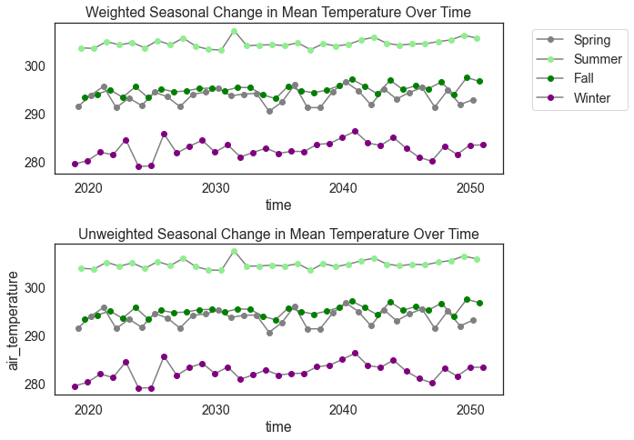

```python
colors = {3: "grey", 6: "lightgreen", 9: "green", 12: "purple"}
seasons = {3: "Spring", 6: "Summer", 9: "Fall", 12: "Winter"}

f, (ax1, ax2) = plt.subplots(2, 1, figsize=(10, 7), sharey=True)
for month, arr in mary_weighted_season_value.groupby('time.month'):
    arr.plot(ax=ax1,
             color="grey",
             marker="o",
             markerfacecolor=colors[month],
             markeredgecolor=colors[month],
             label=seasons[month])

ax1.legend(bbox_to_anchor=(1.05, 1), loc='upper left')
ax1.set(title="Weighted Seasonal Change in Mean Temperature Over Time")

for month, arr in mary_seasonal_mean.groupby('time.month'):
    arr.plot(ax=ax2,
             color="grey",
             marker="o",
             markerfacecolor=colors[month],
             markeredgecolor=colors[month],
             label=seasons[month])

ax2.set(title="Unweighted Seasonal Change in Mean Temperature Over Time")
f.tight_layout()
plt.show()
```

```python
# What does the difference look like weighted vs unweighted?
mary_seasonal_mean - mary_weighted_season_value
```

```
<xarray.DataArray (time: 129, region: 1)>
array([[-0.1152987 ],
       [ 0.01128311],
       [ 0.1946707 ],
       [ 0.00089923],
       [-0.02174739],
       [ 0.07477523],
       [ 0.1770767 ],
       [ 0.11014661],
       [-0.0848315 ],
       [ 0.07148991],
       [ 0.14094146],
       [ 0.01639285],
       [-0.25586202],
       [ 0.10104348],
       [ 0.02336707],
       [ 0.09752564],
       [-0.17173879],
       [ 0.06372326],
       [ 0.22903081],
       [ 0.15537952],
...
       [ 0.03827022],
       [ 0.07924979],
       [ 0.00988923],
       [-0.04448863],
       [ 0.02750582],
       [ 0.16924404],
       [ 0.02565074],
       [-0.14312508],
       [ 0.13465801],
       [ 0.16500616],
       [-0.03209731],
       [-0.07892549],
       [-0.00186343],
       [ 0.13318772],
       [-0.06560735],
       [-0.17114156],
       [ 0.18689524],
       [ 0.1257746 ],
       [ 0.00707667],
       [-0.16119466]])
Coordinates:
  * time     (time) object 2018-12-01 00:00:00 ... 2050-12-01 00:00:00
  * region   (region) int32 69
```

# Further reading

1.Python Programming for Data Processing and Climate Analysis [link](https://www2.atmos.umd.edu/~dkleist/docs/pythonTraining/Slides/netCDF4Matplotlib_SSSO.pdf).

2.NEX-GDDP: Global Daily Downscaled Projections for Studies of Climate Change Impacts [link](https://esgf.nccs.nasa.gov/esgdoc/NEX-GDDP_Tech_Note_v0.pdf).

3.Using Python in Climate and Meteorology [link](https://www.johnny-lin.com/presn/using_python11.pdf)

## Conclusion

The work described in this notebook is show you how to determine climate change(air temperature) using netcdf data by using different numpy and xarray techniques.

# Next Step

There is still much room to dig further . For example, Use same data manipulation techniques to explore the air temperature for East-Coast(pls: don't forget to check your machine memory capacity) and use other climate parameter and see the pattern.